# Analisi demografica di una popolazione reintrodotta di cervo

con effetto della densità dipendenza

# Caso studio

Questo esempio di analisi demografica si basa su un caso studio descritto in Jensen, A. L. (1995). *Simple density-dependent matrix model for population projection.* Ecological Modelling **77**, 43–48.

## La matrice di transizione

La matrice di transizione che descrive la dinamica di popolazione è la seguente:

```r
B <- matrix(c(0.426, 1.290, 1.296, 1.120, 1.126, 1.554, 0,
              0.713, -1, 0, 0, 0, 0, 0,
              0, 0.645, -1, 0, 0, 0, 0,
              0, 0, 0.648, -1, 0, 0, 0,
              0, 0, 0, 0.560, -1, 0, 0,
              0, 0, 0, 0, 0.563, -1, 0,
              0, 0, 0, 0, 0, 0.777, -1),
            nr = 7, byrow = TRUE)

B
```

```
      [,1]   [,2]   [,3]  [,4]   [,5]   [,6] [,7]
[1,] 0.426  1.290  1.296  1.12  1.126  1.554    0
[2,] 0.713 -1.000  0.000  0.00  0.000  0.000    0
[3,] 0.000  0.645 -1.000  0.00  0.000  0.000    0
[4,] 0.000  0.000  0.648 -1.00  0.000  0.000    0
[5,] 0.000  0.000  0.000  0.56 -1.000  0.000    0
[6,] 0.000  0.000  0.000  0.00  0.563 -1.000    0
[7,] 0.000  0.000  0.000  0.00  0.000  0.777   -1
```

Assegniamo dei nomi ai diversi stadi (righe e colonne) della matrice di transizione:

```r
stages <- c("Newborns", "Yearlings", "Juveniles", "Adult1", "Adult2", "Adult3", "Adult3")
```

Uso la funzione *eigen* per calcolare il valore di lambda (tasso di incremento) della mia popolazione di cervo:

```r
# Determinate lambda
eigs.B <- eigen(B)
lambda <- Re(eigs.B[["values"]][1])
lambda
```

```
[1] -1.585997
```

# Simulazione della dinamica di popolazione

Partendo da una popolazione iniziale con un certo numero di animali per ogni classe di età, vado a plottare la dinamica di popolazione per un periodo di 20 anni.  
Per prima cosa creo un vettore N0, che rappresenta la popolazione iniziale, in cui ho soltanto 4 femmine di 1 anno di età. La mia matrice di transizione rappresenta la dinamica della componente femminile della popolazione.

```r
N0 <- matrix(c(0, 4, 0, 0, 0, 0, 0), ncol = 1)
# N0
years <- 20 # anni di simulazione
# years
N.projections <- matrix(0, nrow = nrow(B), ncol = years + 1) # matrice vuota per i risultati
N.projections[, 1] <- N0
N.projections
```

```
     [,1] [,2] [,3] [,4] [,5] [,6] [,7] [,8] [,9] [,10] [,11] [,12] [,13] [,14] [,15]
[1,]    0    0    0    0    0    0    0    0    0     0     0     0     0     0     0
[2,]    4    0    0    0    0    0    0    0    0     0     0     0     0     0     0
[3,]    0    0    0    0    0    0    0    0    0     0     0     0     0     0     0
[4,]    0    0    0    0    0    0    0    0    0     0     0     0     0     0     0
[5,]    0    0    0    0    0    0    0    0    0     0     0     0     0     0     0
[6,]    0    0    0    0    0    0    0    0    0     0     0     0     0     0     0
[7,]    0    0    0    0    0    0    0    0    0     0     0     0     0     0     0
     [,16] [,17] [,18] [,19] [,20] [,21]
[1,]     0     0     0     0     0     0
[2,]     0     0     0     0     0     0
[3,]     0     0     0     0     0     0
[4,]     0     0     0     0     0     0
[5,]     0     0     0     0     0     0
[6,]     0     0     0     0     0     0
[7,]     0     0     0     0     0     0
```

Uso un ciclo *for* per proiettare nel futuro la popolazione. Il ciclo *for* mi permette di ripetere lo stesso calcolo per un determinato numero di volte, corrispondenti al numero di anni di simulazione:

```r
for (i in 1:years) N.projections[, i + 1] <- N.projections[,+ i] +
  matrix(((110-N.projections[,+ i])/110),nr=7) %*% (-lambda) * (N.projections[,+ i])
N.projections
```

```
     [,1]    [,2]     [,3]     [,4]     [,5]     [,6]   [,7]     [,8]     [,9]
[1,]    0  0.0000  0.00000  0.00000  0.00000   0.0000   0.00   0.0000   0.0000
[2,]    4 10.1133 24.67828 55.03705 98.65195 114.7932 106.86 111.6979 108.9635
[3,]    0  0.0000  0.00000  0.00000  0.00000   0.0000   0.00   0.0000   0.0000
[4,]    0  0.0000  0.00000  0.00000  0.00000   0.0000   0.00   0.0000   0.0000
[5,]    0  0.0000  0.00000  0.00000  0.00000   0.0000   0.00   0.0000   0.0000
[6,]    0  0.0000  0.00000  0.00000  0.00000   0.0000   0.00   0.0000   0.0000
[7,]    0  0.0000  0.00000  0.00000  0.00000   0.0000   0.00   0.0000   0.0000
        [,10]    [,11]    [,12]    [,13]    [,14]    [,15]    [,16]    [,17]    [,18]
[1,]   0.0000   0.0000   0.0000   0.0000   0.0000   0.0000   0.0000   0.0000   0.0000
[2,] 110.5919 109.6481 110.2044 109.8796 110.0703 109.9587 110.0242 109.9858 110.0083
[3,]   0.0000   0.0000   0.0000   0.0000   0.0000   0.0000   0.0000   0.0000   0.0000
[4,]   0.0000   0.0000   0.0000   0.0000   0.0000   0.0000   0.0000   0.0000   0.0000
[5,]   0.0000   0.0000   0.0000   0.0000   0.0000   0.0000   0.0000   0.0000   0.0000
[6,]   0.0000   0.0000   0.0000   0.0000   0.0000   0.0000   0.0000   0.0000   0.0000
[7,]   0.0000   0.0000   0.0000   0.0000   0.0000   0.0000   0.0000   0.0000   0.0000
        [,19]    [,20]    [,21]
[1,]   0.0000   0.0000   0.0000
[2,] 109.9951 110.0029 109.9983
[3,]   0.0000   0.0000   0.0000
[4,]   0.0000   0.0000   0.0000
[5,]   0.0000   0.0000   0.0000
[6,]   0.0000   0.0000   0.0000
[7,]   0.0000   0.0000   0.0000
```

Rappresento graficamente il risultato:

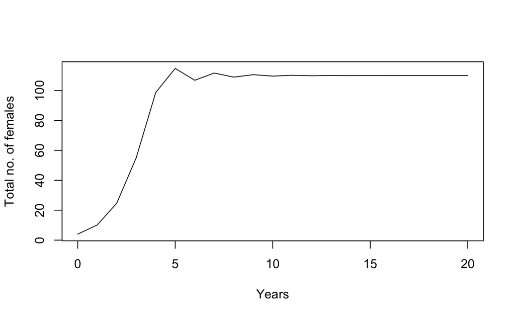

```r
matplot(0:years, rowSums(t(N.projections)), type = "l", ylab="Total no. of females",
        xlab="Years")
```